# Algoritmo Apriori en R

Félix Rodríguez Lagonell

En este informe haremos un ejemplo de implementación de algoritmo apriori en R.

### Instalación de librerías

Cargamos las librerías para el análisis de reglas de asociación arules y para la visualización de rsultados arulesViz.

```r
if (! "arules" %in% installed.packages()) install.packages("arules", dependencies=TRUE)
if (! "arulesViz" %in% installed.packages()) install.packages("arulesViz", dependencies=TRUE)
library(arules)
library(arulesViz)
library(knitr)
```

### Carga de datos

Por simplicidad cargaremos el dataset “Groceries” del paquete arules, el cual contiene las transacciones de un grupo de compras. Si inspeccionamos la clase podemos ver que es de tipo ‘transactions’.

```r
data("Groceries")
class(Groceries)
```

[1] “transactions” attr(,“package”) [1] “arules”

Utilizando la función summary() vemos un resumen del contenido del dataset.

```r
summary(Groceries)
```

transactions as itemMatrix in sparse format with 9835 rows (elements/itemsets/transactions) and 169 columns (items) and a density of 0.02609146

most frequent items: whole milk other vegetables rolls/buns soda 2513 1903 1809 1715 yogurt (Other) 1372 34055

element (itemset/transaction) length distribution: sizes 1 2 3 4 5 6 7 8 9 10 11 12 13 14 15 2159 1643 1299 1005 855 645 545 438 350 246 182 117 78 77 55 16 17 18 19 20 21 22 23 24 26 27 28 29 32 46 29 14 14 9 11 4 6 1 1 1 1 3 1

Min. 1st Qu. Median Mean 3rd Qu. Max. 1.000 2.000 3.000 4.409 6.000 32.000

includes extended item information - examples: labels level2 level1 1 frankfurter sausage meat and sausage 2 sausage sausage meat and sausage 3 liver loaf sausage meat and sausage

Básicamente contiene 9835 transacciones=filas (compras) y 169 columnas (elementos o productos).

No siempre tendremos los datos en formato ‘transactions’, por lo que arules cuenta con la función as(“transactions”) para pasar de listas o dataframes a un objeto de este tipo. A continuación mostraremos un ejemplo para pasar un dataframe en modo filas (transid1, element1), (transid2, element2) … (transidn, elementn) que es como solemos almacenar la información en las tablas de las bases de datos relacionales.

```r
a_df3 <- data.frame(TID = c(1, 1, 2, 2, 2, 3), item = c("a", "b", "a", "b", "c", "b"))
a_df3
```

TID item 1 1 a 2 1 b 3 2 a 4 2 b 5 2 c 6 3 b

```r
trans4 <- as(split(a_df3[, "item"], a_df3[, "TID"]), "transactions")
trans4
```

transactions in sparse format with 3 transactions (rows) and 3 items (columns)

Volviendo al dataset ‘Groceries’, podemos ver qué pinta tienen las tres primeras transacciones. Utilizamos la función inspect() del paquete arules junto con la función head() para limitar el número de registros a mostrar

```r
# inspect(Groceries[1:3])

inspect(head(Groceries, n=3))
```

```
items
```

[1] {citrus fruit,  
semi-finished bread, margarine,  
ready soups}  
[2] {tropical fruit,  
yogurt,  
coffee}  
[3] {whole milk}

### Análisis exploratorio

Iniciamos un breve análisis exploratorio para ver las principales características de nuestro dataset. En primer lugar vamos a ver el conjunto de elementos que lo forma

```r
itemLabels(Groceries)
```

[1] “frankfurter” “sausage”  
[3] “liver loaf” “ham”  
[5] “meat” “finished products”  
[7] “organic sausage” “chicken”  
[9] “turkey” “pork”  
[11] “beef” “hamburger meat”  
[13] “fish” “citrus fruit”  
[15] “tropical fruit” “pip fruit”  
[17] “grapes” “berries”  
[19] “nuts/prunes” “root vegetables”  
[21] “onions” “herbs”  
[23] “other vegetables” “packaged fruit/vegetables” [25] “whole milk” “butter”  
[27] “curd” “dessert”  
[29] “butter milk” “yogurt”  
[31] “whipped/sour cream” “beverages”  
[33] “UHT-milk” “condensed milk”  
[35] “cream” “soft cheese”  
[37] “sliced cheese” “hard cheese”  
[39] “cream cheese” “processed cheese”  
[41] “spread cheese” “curd cheese”  
[43] “specialty cheese” “mayonnaise”  
[45] “salad dressing” “tidbits”  
[47] “frozen vegetables” “frozen fruits”  
[49] “frozen meals” “frozen fish”  
[51] “frozen chicken” “ice cream”  
[53] “frozen dessert” “frozen potato products”  
[55] “domestic eggs” “rolls/buns”  
[57] “white bread” “brown bread”  
[59] “pastry” “roll products”  
[61] “semi-finished bread” “zwieback”  
[63] “potato products” “flour”  
[65] “salt” “rice”  
[67] “pasta” “vinegar”  
[69] “oil” “margarine”  
[71] “specialty fat” “sugar”  
[73] “artif. sweetener” “honey”  
[75] “mustard” “ketchup”  
[77] “spices” “soups”  
[79] “ready soups” “Instant food products”  
[81] “sauces” “cereals”  
[83] “organic products” “baking powder”  
[85] “preservation products” “pudding powder”  
[87] “canned vegetables” “canned fruit”  
[89] “pickled vegetables” “specialty vegetables”  
[91] “jam” “sweet spreads”  
[93] “meat spreads” “canned fish”  
[95] “dog food” “cat food”  
[97] “pet care” “baby food”  
[99] “coffee” “instant coffee”  
[101] “tea” “cocoa drinks”  
[103] “bottled water” “soda”  
[105] “misc. beverages” “fruit/vegetable juice”  
[107] “syrup” “bottled beer”  
[109] “canned beer” “brandy”  
[111] “whisky” “liquor”  
[113] “rum” “liqueur”  
[115] “liquor (appetizer)” “white wine”  
[117] “red/blush wine” “prosecco”  
[119] “sparkling wine” “salty snack”  
[121] “popcorn” “nut snack”  
[123] “snack products” “long life bakery product” [125] “waffles” “cake bar”  
[127] “chewing gum” “chocolate”  
[129] “cooking chocolate” “specialty chocolate”  
[131] “specialty bar” “chocolate marshmallow”  
[133] “candy” “seasonal products”  
[135] “detergent” “softener”  
[137] “decalcifier” “dish cleaner”  
[139] “abrasive cleaner” “cleaner”  
[141] “toilet cleaner” “bathroom cleaner”  
[143] “hair spray” “dental care”  
[145] “male cosmetics” “make up remover”  
[147] “skin care” “female sanitary products” [149] “baby cosmetics” “soap”  
[151] “rubbing alcohol” “hygiene articles”  
[153] “napkins” “dishes”  
[155] “cookware” “kitchen utensil”  
[157] “cling film/bags” “kitchen towels”  
[159] “house keeping products” “candles”  
[161] “light bulbs” “sound storage medium”  
[163] “newspapers” “photo/film”  
[165] “pot plants” “flower soil/fertilizer”  
[167] “flower (seeds)” “shopping bags”  
[169] “bags”

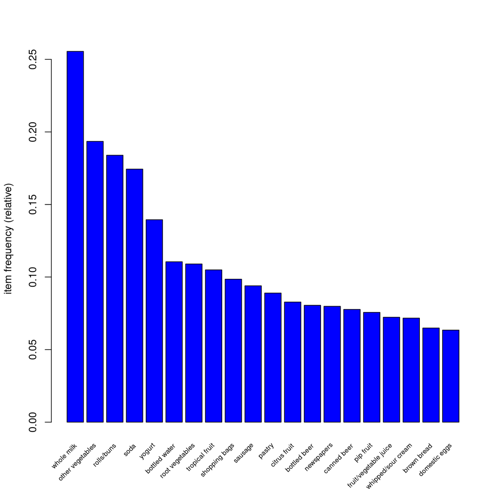

```r
itemFrequencyPlot(Groceries, topN=20, col="blue", cex.names=.65)
```

La leche entera está en el 25% de las compras.

Si queremos filtrar las compras en las que se adquiere un producto en particular podemos utilizar la función subset() con alguna condición. Por ejemplo todas las compras en las que se adquieren periódicos.

```r
news <- subset(Groceries, items %in% "newspapers")
dim(news)
```

```
## [1] 785 169
```

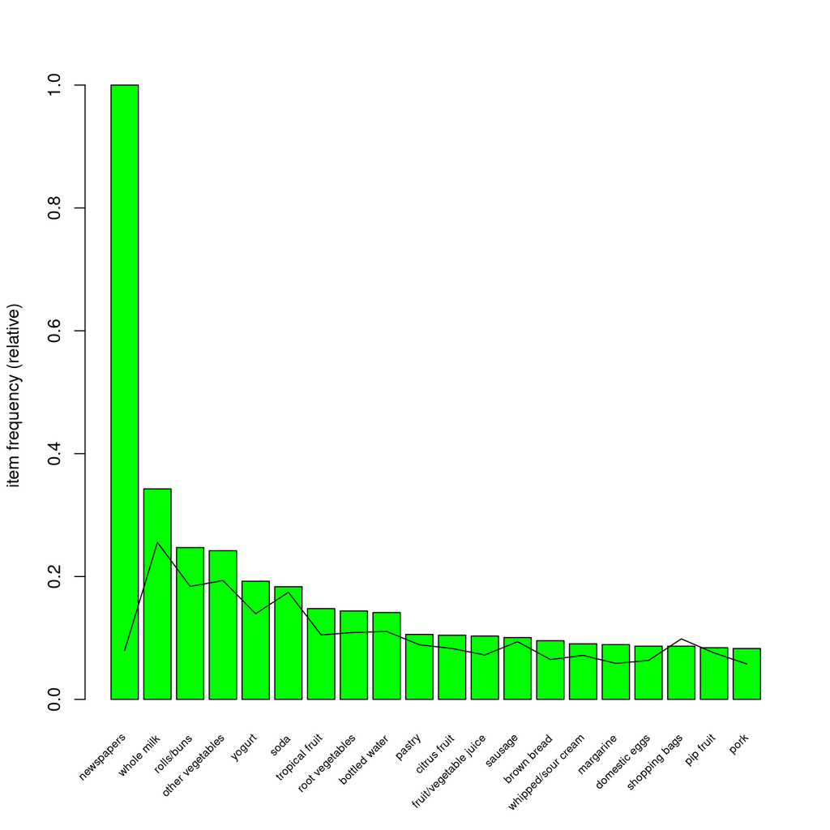

```r
itemFrequencyPlot(news, topN=20, population=Groceries, col="green", cex.names=.65)
```

### Reglas de asociación

Obtendremos las reglas de asociación con la función apriori(). Recordemos que tenemos que fijar al menos un soporte mínimo. En este caso vamos a quedarnos con las asociaciones que ocurran al menos en 10 compras del dataset completo, que incluye unas 10000. Por tanto minsup=0.001

```r
# reglas <- apriori(Groceries, parameter=list(support=.001, conf=0.8))


reglas <- apriori(Groceries, parameter=list(support=.001))
```

Apriori

Parameter specification: confidence minval smax arem aval originalSupport maxtime support minlen 0.8 0.1 1 none FALSE TRUE 5 0.001 1 maxlen target ext 10 rules FALSE

Algorithmic control: filter tree heap memopt load sort verbose 0.1 TRUE TRUE FALSE TRUE 2 TRUE

Absolute minimum support count: 9

set item appearances …[0 item(s)] done [0.00s]. set transactions …[169 item(s), 9835 transaction(s)] done [0.00s]. sorting and recoding items … [157 item(s)] done [0.00s]. creating transaction tree … done [0.00s]. checking subsets of size 1 2 3 4 5 6 done [0.01s]. writing … [410 rule(s)] done [0.00s]. creating S4 object … done [0.00s].

```r
summary(reglas)
```

set of 410 rules

rule length distribution (lhs + rhs):sizes 3 4 5 6 29 229 140 12

Min. 1st Qu. Median Mean 3rd Qu. Max. 3.000 4.000 4.000 4.329 5.000 6.000

summary of quality measures: support confidence lift count  
Min. :0.001017 Min. :0.8000 Min. : 3.131 Min. :10.00  
1st Qu.:0.001017 1st Qu.:0.8333 1st Qu.: 3.312 1st Qu.:10.00  
Median :0.001220 Median :0.8462 Median : 3.588 Median :12.00  
Mean :0.001247 Mean :0.8663 Mean : 3.951 Mean :12.27  
3rd Qu.:0.001322 3rd Qu.:0.9091 3rd Qu.: 4.341 3rd Qu.:13.00  
Max. :0.003152 Max. :1.0000 Max. :11.235 Max. :31.00

mining info: data ntransactions support confidence Groceries 9835 0.001 0.8

El detalle a través de la función summary() nos da información muy interesante del conjunto de reglas:

1. Hay 410 reglas que cumplen con la condición del soporte mínimo.
2. La distribución del tamaño de las reglas (número de productos).
3. Por defecto aplica la condición de confianza mínima utilizando un valor de 0.8. Si se quiere valor este valor desde el inicio se puede indicar en los parámetros de la función apriori()

También podemos inspeccionar las reglas. En este caso las vamos a ordenar para que salgan las más relevantes arriba.

```r
inspect(sort(reglas, by="lift")[1:20])
```

```
 lhs                        rhs                   support confidence      lift count
```

[1] {liquor,  
red/blush wine} => {bottled beer} 0.001931876 0.9047619 11.235269 19 [2] {citrus fruit,  
other vegetables,  
soda,  
fruit/vegetable juice} => {root vegetables} 0.001016777 0.9090909 8.340400 10 [3] {tropical fruit,  
other vegetables,  
whole milk,  
yogurt,  
oil} => {root vegetables} 0.001016777 0.9090909 8.340400 10 [4] {citrus fruit,  
grapes,  
fruit/vegetable juice} => {tropical fruit} 0.001118454 0.8461538 8.063879 11 [5] {other vegetables,  
whole milk,  
yogurt,  
rice} => {root vegetables} 0.001321810 0.8666667 7.951182 13 [6] {tropical fruit,  
other vegetables,  
whole milk,  
oil} => {root vegetables} 0.001321810 0.8666667 7.951182 13 [7] {ham,  
pip fruit,  
other vegetables,  
yogurt} => {tropical fruit} 0.001016777 0.8333333 7.941699 10 [8] {beef,  
citrus fruit,  
tropical fruit,  
other vegetables} => {root vegetables} 0.001016777 0.8333333 7.645367 10 [9] {root vegetables,  
butter,  
cream cheese } => {yogurt} 0.001016777 0.9090909 6.516698 10 [10] {tropical fruit,  
whole milk,  
butter,  
sliced cheese} => {yogurt} 0.001016777 0.9090909 6.516698 10 [11] {other vegetables,  
curd,  
whipped/sour cream,  
cream cheese } => {yogurt} 0.001016777 0.9090909 6.516698 10 [12] {tropical fruit,  
other vegetables,  
butter,  
white bread} => {yogurt} 0.001016777 0.9090909 6.516698 10 [13] {sausage,  
pip fruit,  
sliced cheese} => {yogurt} 0.001220132 0.8571429 6.144315 12 [14] {tropical fruit,  
whole milk,  
butter,  
curd} => {yogurt} 0.001220132 0.8571429 6.144315 12 [15] {tropical fruit,  
butter,  
white bread} => {yogurt} 0.001118454 0.8461538 6.065542 11 [16] {tropical fruit,  
butter,  
margarine} => {yogurt} 0.001118454 0.8461538 6.065542 11 [17] {whole milk,  
curd,  
whipped/sour cream,  
cream cheese } => {yogurt} 0.001118454 0.8461538 6.065542 11 [18] {whipped/sour cream,  
cream cheese ,  
margarine} => {yogurt} 0.001016777 0.8333333 5.973639 10 [19] {beef,  
tropical fruit,  
butter} => {yogurt} 0.001016777 0.8333333 5.973639 10 [20] {pork,  
tropical fruit,  
fruit/vegetable juice} => {yogurt} 0.001016777 0.8333333 5.973639 10

Si queremos quedarnos con las reglas que cumplen criterios mínimos de soporte y confianza e incluyan algún producto en particular (newspaper)…

```r
inspect(subset(reglas, items %in% "newspapers"))
```

```
lhs                  rhs                    support confidence     lift count
```

[1] {citrus fruit,  
root vegetables,  
newspapers} => {other vegetables} 0.001626843 0.8421053 4.352131 16 [2] {citrus fruit,  
root vegetables,  
whole milk,  
newspapers} => {other vegetables} 0.001016777 0.8333333 4.306796 10 [3] {tropical fruit,  
whole milk,  
soda,  
newspapers} => {other vegetables} 0.001118454 0.8461538 4.373055 11 [4] {whole milk,  
rolls/buns,  
soda,  
newspapers} => {other vegetables} 0.001016777 1.0000000 5.168156 10

En este caaso sólo 4 reglas que asocian periódicos con otros productos cumplen con los criterios de soporte y confianza.

Se podría selecionar las reglas que cumplen con los criterios de soporte y confianza, pero que no contengan un determinado artículo…

```r
subset(reglas, !items %in% "newspapers")
```

set of 406 rules

Como es obvio, por lo que habíamos visto anteriormente, que teníamos 410 reglas en total y había 4 conteniendo newspaper, ahora tenemos 406 que no contienen dicho producto.

### Visualizaciones

Veamos algunas visualizaciones con la librería arulesViz.

Empezamos con un gráfico que muestra como se distribuyen las reglas en base a las variables de soporte, confianza y lift.

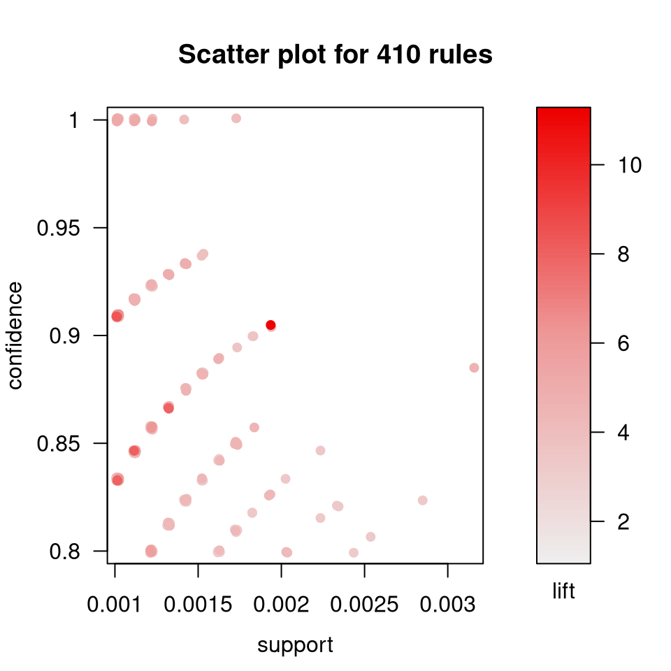

```r
plot(reglas)
```

A continuación un diagrama de bolas muy sencillo de interpretar. En el eje horizontal están representados los miembros LHS (izquierda) de la regla y en el eje vertical los RHS (derecha). Cuanto mayor es el radio de la bola mayor es el soporte de la regla y cuanto más anaranjado el color mayor es el lift.

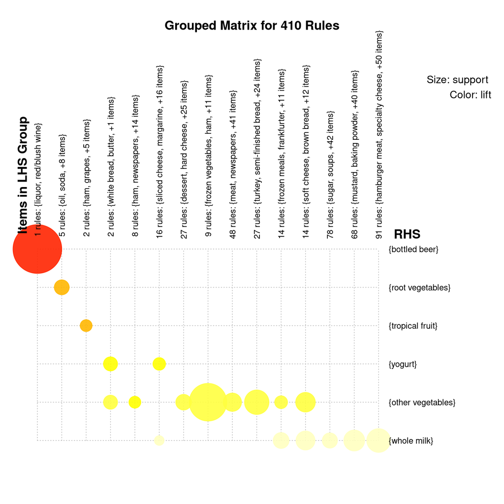

```r
plot(reglas, method="grouped", control=list(k=15, col=heat.colors(10)))
```

Las reglas más importantes serán aquellas con un radio de bola mayor y que tuvieran un color más intenso, como es el caso de (liquor => bottled beer).

Otra visualización bastante utilizada es representar las reglas en modo grafo.

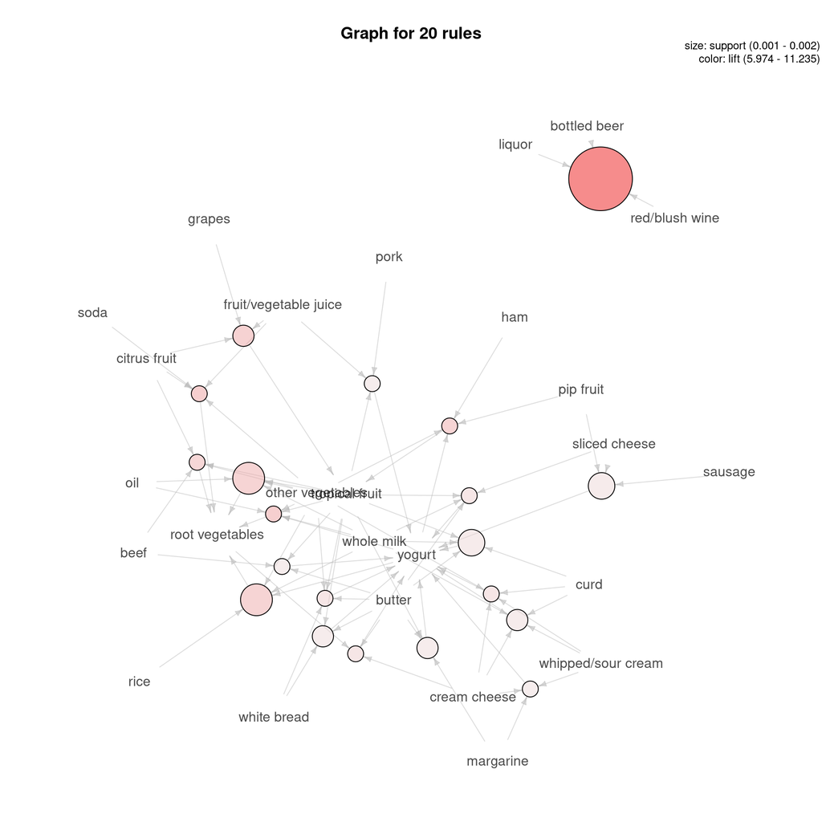

[output not shown]

```r
plot(sort(reglas, by="lift")[1:20], method="graph", control=list(type="items"))
```

### Otros algoritmos de reglas de asociación

- ECLAT (Equivalence CLAss Transformation)
- arulesNBMiner
- FP-Growth